# Tan_Chuan_Xin_CBA_rcode

tanchuanxin

11/7/2021

# Setup

In this chunk, we will set up the R libraries necessary for this assignment. Also, we will read in the data from `premium2.csv` as a data table and perform a quick check on the first few rows of the data to ensure we have read it in successfully

```r
knitr::opts_chunk$set(echo = TRUE)
library(knitr) # for rmarkdown
library(data.table) # for data tables
library(tidyverse) # for data manipulation
```

```r
library(ggplot2) # for visualization
library(corrplot) # for correlation plot
library(cowplot) # for stitching graphs
library(caTools) # for train-test split
library(rpart) # for cart
library(rpart.plot) # for plotting cart
library(car) # for vif
library(caret) # for linreg cv
# set your working directory here
setwd("C:/Users/user/Documents/Github/re6013_assignment") # chuanxin's wd

# set a seed so that random things are repeatable
set.seed(2021)
```

```r
# read in data
premium2.dt <- fread("premium2.csv")


# check data
dim(premium2.dt)
```

```
## [1] 988  12
```

```r
head(premium2.dt)
```

```
##    Age Diabetes HighBloodPressure Transplant ChronicDisease Height Weight
## 1:  45        0                 0          0              0    155     57
## 2:  60        1                 0          0              0    180     73
## 3:  36        1                 1          0              0    158     59
## 4:  52        1                 1          0              1    183     93
## 5:  38        0                 0          0              1    166     88
## 6:  30        0                 0          0              0    160     69
##    Allergy CancerInFamily NumMajorSurgeries Gender Premium
## 1:       0              0                 0      0    1250
## 2:       0              0                 0      1    1450
## 3:       0              0                 1      1    1150
## 4:       0              0                 2      0    1400
## 5:       0              0                 1      1    1150
## 6:       1              0                 1      1    1150
```

```r
summary(premium2.dt)
```

```
##       Age           Diabetes     HighBloodPressure   Transplant
##  Min.   :18.00   Min.   :0.000   Min.   :0.0000    Min.   :0.00000
##  1st Qu.:30.00   1st Qu.:0.000   1st Qu.:0.0000    1st Qu.:0.00000
##  Median :42.00   Median :0.000   Median :0.0000    Median :0.00000
##  Mean   :41.72   Mean   :0.419   Mean   :0.4686    Mean   :0.05567
##  3rd Qu.:53.00   3rd Qu.:1.000   3rd Qu.:1.0000    3rd Qu.:0.00000
##  Max.   :66.00   Max.   :1.000   Max.   :1.0000    Max.   :1.00000
##  ChronicDisease       Height          Weight          Allergy
##  Min.   :0.0000   Min.   :145.0   Min.   : 51.00   Min.   :0.0000
##  1st Qu.:0.0000   1st Qu.:161.0   1st Qu.: 67.00   1st Qu.:0.0000
##  Median :0.0000   Median :168.0   Median : 75.00   Median :0.0000
##  Mean   :0.1802   Mean   :168.2   Mean   : 76.92   Mean   :0.2146
##  3rd Qu.:0.0000   3rd Qu.:176.0   3rd Qu.: 87.00   3rd Qu.:0.0000
##  Max.   :1.0000   Max.   :188.0   Max.   :132.00   Max.   :1.0000
##  CancerInFamily   NumMajorSurgeries     Gender          Premium
##  Min.   :0.0000   Min.   :0.000     Min.   :0.0000   Min.   : 750
##  1st Qu.:0.0000   1st Qu.:0.000     1st Qu.:0.0000   1st Qu.:1050
##  Median :0.0000   Median :1.000     Median :0.0000   Median :1150
##  Mean   :0.1174   Mean   :0.666     Mean   :0.4575   Mean   :1216
##  3rd Qu.:0.0000   3rd Qu.:1.000     3rd Qu.:1.0000   3rd Qu.:1400
##  Max.   :1.0000   Max.   :3.000     Max.   :1.0000   Max.   :2000
```

# Question 1

**Create the BMI variable based on CDC definition from https://www.cdc.gov/healthyweight/assessing/index.html. Show your code.**

From the website, `BMI is a person’s weight in kilograms divided by the square of height in meters`. We shall implement this formula to create the BMI variable.

We reference Appendix A of `CBA Question Paper.pdf` and see that the `Height` variable is given in cm, while the `Weight` variable is given in kg. Therefore, we will have to perform some conversion for the height variable before using it.

The formula is therefore `BMI = Weight / (Height/100)^2`. We will keep BMI as a variable type of Double because the decimal points are important. However, we will round off to just one decimal point.

```r
# create the BMI variable
premium2.dt$BMI <- round(premium2.dt$Weight / ((premium2.dt$Height/100)^2), 1)
head(premium2.dt$BMI)
```

```
## [1] 23.7 22.5 23.6 27.8 31.9 27.0
```

```r
summary(premium2.dt$BMI)
```

```
##    Min. 1st Qu.  Median    Mean 3rd Qu.    Max.
##   15.20   23.38   27.15   27.45   30.80   50.00
```

```r
# check data
dim(premium2.dt)
```

```
## [1] 988  13
```

```r
head(premium2.dt)
```

```
##    Age Diabetes HighBloodPressure Transplant ChronicDisease Height Weight
## 1:  45        0                 0          0              0    155     57
## 2:  60        1                 0          0              0    180     73
## 3:  36        1                 1          0              0    158     59
## 4:  52        1                 1          0              1    183     93
## 5:  38        0                 0          0              1    166     88
## 6:  30        0                 0          0              0    160     69
##    Allergy CancerInFamily NumMajorSurgeries Gender Premium  BMI
## 1:       0              0                 0      0    1250 23.7
## 2:       0              0                 0      1    1450 22.5
## 3:       0              0                 1      1    1150 23.6
## 4:       0              0                 2      0    1400 27.8
## 5:       0              0                 1      1    1150 31.9
## 6:       1              0                 1      1    1150 27.0
```

```r
summary(premium2.dt)
```

```
##       Age           Diabetes     HighBloodPressure   Transplant
##  Min.   :18.00   Min.   :0.000   Min.   :0.0000    Min.   :0.00000
##  1st Qu.:30.00   1st Qu.:0.000   1st Qu.:0.0000    1st Qu.:0.00000
##  Median :42.00   Median :0.000   Median :0.0000    Median :0.00000
##  Mean   :41.72   Mean   :0.419   Mean   :0.4686    Mean   :0.05567
##  3rd Qu.:53.00   3rd Qu.:1.000   3rd Qu.:1.0000    3rd Qu.:0.00000
##  Max.   :66.00   Max.   :1.000   Max.   :1.0000    Max.   :1.00000
##  ChronicDisease       Height          Weight          Allergy
##  Min.   :0.0000   Min.   :145.0   Min.   : 51.00   Min.   :0.0000
##  1st Qu.:0.0000   1st Qu.:161.0   1st Qu.: 67.00   1st Qu.:0.0000
##  Median :0.0000   Median :168.0   Median : 75.00   Median :0.0000
##  Mean   :0.1802   Mean   :168.2   Mean   : 76.92   Mean   :0.2146
##  3rd Qu.:0.0000   3rd Qu.:176.0   3rd Qu.: 87.00   3rd Qu.:0.0000
##  Max.   :1.0000   Max.   :188.0   Max.   :132.00   Max.   :1.0000
##  CancerInFamily   NumMajorSurgeries     Gender          Premium
##  Min.   :0.0000   Min.   :0.000     Min.   :0.0000   Min.   : 750
##  1st Qu.:0.0000   1st Qu.:0.000     1st Qu.:0.0000   1st Qu.:1050
##  Median :0.0000   Median :1.000     Median :0.0000   Median :1150
##  Mean   :0.1174   Mean   :0.666     Mean   :0.4575   Mean   :1216
##  3rd Qu.:0.0000   3rd Qu.:1.000     3rd Qu.:1.0000   3rd Qu.:1400
##  Max.   :1.0000   Max.   :3.000     Max.   :1.0000   Max.   :2000
##       BMI
##  Min.   :15.20
##  1st Qu.:23.38
##  Median :27.15
##  Mean   :27.45
##  3rd Qu.:30.80
##  Max.   :50.00
```

# Question 2

**There are many categorical variables with integer coded values (e.g. Diabetes, HighBloodPressure, Transplant…etc.) Is it necessary to convert them to factor datatype in R?**

Yes, it is necessary to convert them into factor datatype in R. If we wrongly interpret the categorical variables as continuous variables, this allows for numeric concepts on continuous numbers such as fractions to become applicable.

Taking the example of the `Gender` variable, a value of 0.5 would mean that the person is halfway male and female, which is not possible. Or for the `Allergy` variable, the interpretation would be that the person has half an allergy which makes no sense as well.

Hence, it is necessary to convert categorical variables with integer coded values into factor datatype in R.

# Question 3

**Explore the data and report on your key findings.**

### Variable Typing

In this chunk, we reference Appendix A of `CBA Question Paper.pdf`. Appendix A provides a data dictionary that specifies what each of the features/variables in `premium2.csv` mean. We will alter the data table accordingly to match the description in Appendix A, such that we analyze each feature the way it is meant to be analyzed.

```r
# Age: Age of the client (years)
#       --> continuous variable, integer variable type, no change needed


# Diabetes: Presence (1) or Absence (0) of the disease.
#       --> unordered factor variable, integer variable type. turn it into a factor
premium2.dt$Diabetes <- factor(premium2.dt$Diabetes, levels = c(0, 1), labels = c("No", "Yes"))
# premium2.dt$Diabetes <- factor(premium2.dt$Diabetes, levels = c(0, 1))


# HighBloodPressure: Presence (1) or Absence (0) of the disease.
#       --> unordered factor variable, integer variable type. turn it into a factor
premium2.dt$HighBloodPressure <- factor(premium2.dt$HighBloodPressure, levels = c(0, 1), labels = c("No", "Yes"))
# premium2.dt$HighBloodPressure <- factor(premium2.dt$HighBloodPressure, levels = c(0, 1))


# Transplant: Organ Transplant Surgery Ever Done (1: Yes, 0: No).
#       --> unordered factor variable, integer variable type. turn it into a factor
premium2.dt$Transplant <- factor(premium2.dt$Transplant, levels = c(0, 1), labels = c("No", "Yes"))
# premium2.dt$Transplant <- factor(premium2.dt$Transplant, levels = c(0, 1))


# ChronicDisease: Other Chronic Disease besides Diabetes or High Blood Pressure (1: Yes, 0: No).
#       --> unordered factor variable, integer variable type turn it into a factor
premium2.dt$ChronicDisease <- factor(premium2.dt$ChronicDisease, levels = c(0, 1), labels = c("No", "Yes"))
# premium2.dt$ChronicDisease <- factor(premium2.dt$ChronicDisease, levels = c(0, 1))


# Height: Height (cm).
#       --> continuous variable, integer variable type, no change needed


# Weight: Weight (kg).
#       --> continuous variable, integer variable type, no change needed


# Allergy: Known Allergy (1: Yes, 0: No).
#       --> unordered factor variable, integer variable type. turn it into a factor
premium2.dt$Allergy <- factor(premium2.dt$Allergy, levels = c(0, 1), labels = c("No", "Yes"))
# premium2.dt$Allergy <- factor(premium2.dt$Allergy, levels = c(0, 1))


# CancerInFamily: Does any family member had/have Cancer (1: Yes, 0: No).
#       --> unordered factor variable, integer variable type turn it into a factor
premium2.dt$CancerInFamily <- factor(premium2.dt$CancerInFamily, levels = c(0, 1), labels = c("No", "Yes"))
# premium2.dt$CancerInFamily <- factor(premium2.dt$CancerInFamily, levels = c(0, 1))


# NumMajorSurgeries: Number of Major Surgeries Done, excluding Organ Transplant.
#       --> continuous variable, integer variable type
#       --> however, while NumMajorSurgeries could theoretically take on any continuous integer value, it practically is limited to very few values because a human can only go through that many major surgeries. therefore, an argument can be made for this to be a factor variable
#       --> particularly in this case, where NumMajorSurgeries only takes on integers 0,1,2,3, we should treat it as a factor variable
premium2.dt$NumMajorSurgeries <- factor(premium2.dt$NumMajorSurgeries, levels = c(0, 1, 2, 3), labels = c(0, 1, 2, 3))
# premium2.dt$NumMajorSurgeries <- factor(premium2.dt$NumMajorSurgeries, levels = c(0, 1, 2, 3))


# Gender: (1: Male, 0: Female).
#       --> unordered factor variable, integer variable type turn it into a factor
premium2.dt$Gender <- factor(premium2.dt$Gender, levels = c(0, 1), labels = c("Female", "Male"))
# premium2.dt$Gender <- factor(premium2.dt$Gender, levels = c(0, 1))


# Premium: Annual Premium Payable by client (Singapore Dollars)
#       --> continuous variable, integer variable type, no change needed


# BMI: continuous variable created in Question 1. It is a ratio
#       --> continuous variable, double variable type, no change needed


# check data
dim(premium2.dt)
```

```
## [1] 988  13
```

```r
head(premium2.dt)
```

```
##    Age Diabetes HighBloodPressure Transplant ChronicDisease Height Weight
## 1:  45       No                No         No             No    155     57
## 2:  60      Yes                No         No             No    180     73
## 3:  36      Yes               Yes         No             No    158     59
## 4:  52      Yes               Yes         No            Yes    183     93
## 5:  38       No                No         No            Yes    166     88
## 6:  30       No                No         No             No    160     69
##    Allergy CancerInFamily NumMajorSurgeries Gender Premium  BMI
## 1:      No             No                 0 Female    1250 23.7
## 2:      No             No                 0   Male    1450 22.5
## 3:      No             No                 1   Male    1150 23.6
## 4:      No             No                 2 Female    1400 27.8
## 5:      No             No                 1   Male    1150 31.9
## 6:     Yes             No                 1   Male    1150 27.0
```

```r
summary(premium2.dt)
```

```
##       Age        Diabetes  HighBloodPressure Transplant ChronicDisease
##  Min.   :18.00   No :574   No :525           No :933    No :810
##  1st Qu.:30.00   Yes:414   Yes:463           Yes: 55    Yes:178
##  Median :42.00
##  Mean   :41.72
##  3rd Qu.:53.00
##  Max.   :66.00
##      Height          Weight       Allergy   CancerInFamily NumMajorSurgeries
##  Min.   :145.0   Min.   : 51.00   No :776   No :872        0:481
##  1st Qu.:161.0   1st Qu.: 67.00   Yes:212   Yes:116        1:372
##  Median :168.0   Median : 75.00                            2:119
##  Mean   :168.2   Mean   : 76.92                            3: 16
##  3rd Qu.:176.0   3rd Qu.: 87.00
##  Max.   :188.0   Max.   :132.00
##     Gender       Premium          BMI
##  Female:536   Min.   : 750   Min.   :15.20
##  Male  :452   1st Qu.:1050   1st Qu.:23.38
##               Median :1150   Median :27.15
##               Mean   :1216   Mean   :27.45
##               3rd Qu.:1400   3rd Qu.:30.80
##               Max.   :2000   Max.   :50.00
```

### Data Cleaning

In this chunk, we will also perform a check for NA/missing data and resolve those, as well as impossible/illogical data from the data table such as negative age (if any). We make use of the summary table that was generated above. We may resolve outliers here if necessary.

```r
# check for missing data, such as NA etc
any(is.na(premium2.dt))
```

```
## [1] FALSE
```

```r
#       --> there are no missing data, all good!

min(premium2.dt$Age)
```

```
## [1] 18
```

```r
max(premium2.dt$Age)
```

```
## [1] 66
```

```r
# check Age: min=18, max=66
#       --> acceptable range

min(premium2.dt$Height)
```

```
## [1] 145
```

```r
max(premium2.dt$Height)
```

```
## [1] 188
```

```r
# check Height: min=145, max=188
#       --> acceptable range

min(premium2.dt$Weight)
```

```
## [1] 51
```

```r
max(premium2.dt$Weight)
```

```
## [1] 132
```

```r
# check Weight: Weight=51, max=132
#       --> take a look at those with very high weights, just to be sure
checkWeight.dt <- premium2.dt %>%
  filter(Weight >= 100)
checkWeight.dt
```

```
##     Age Diabetes HighBloodPressure Transplant ChronicDisease Height Weight
##  1:  47       No                No         No             No    169    116
##  2:  21       No                No         No             No    157    118
##  3:  62      Yes                No         No            Yes    167    110
##  4:  43       No                No         No             No    158    121
##  5:  58      Yes               Yes         No             No    180    116
##  6:  32       No                No         No             No    167    104
##  7:  55       No                No         No             No    162    116
##  8:  35       No               Yes         No             No    174    106
##  9:  36       No                No         No             No    156    119
## 10:  30      Yes               Yes         No             No    161    107
## 11:  19       No                No         No             No    173    129
## 12:  25      Yes               Yes        Yes             No    157    109
## 13:  35      Yes                No         No             No    164    100
## 14:  48       No                No         No             No    176    109
```

[output cut: 83 more lines]

```r
# turns out, there are 47 entries of people with Weight >= 100kg. This suggests that the maximum weight of 132kg is not an anomaly/outlier, and does not need to be removed
#       --> acceptable range... if you can say 132kg is acceptable

min(premium2.dt$Premium)
```

```
## [1] 750
```

```r
max(premium2.dt$Premium)
```

```
## [1] 2000
```

```r
# check Premium: min=750, max=2000
#       --> acceptable range

min(premium2.dt$BMI)
```

```
## [1] 15.2
```

```r
max(premium2.dt$BMI)
```

```
## [1] 50
```

```r
# check BMI: min=15.2, max=50
#       --> acceptable range, since we find the original range of values of Height and Weight to be acceptable


# check data
dim(premium2.dt)
```

```
## [1] 988  13
```

```r
head(premium2.dt)
```

```
##    Age Diabetes HighBloodPressure Transplant ChronicDisease Height Weight
## 1:  45       No                No         No             No    155     57
## 2:  60      Yes                No         No             No    180     73
## 3:  36      Yes               Yes         No             No    158     59
## 4:  52      Yes               Yes         No            Yes    183     93
## 5:  38       No                No         No            Yes    166     88
## 6:  30       No                No         No             No    160     69
##    Allergy CancerInFamily NumMajorSurgeries Gender Premium  BMI
## 1:      No             No                 0 Female    1250 23.7
## 2:      No             No                 0   Male    1450 22.5
## 3:      No             No                 1   Male    1150 23.6
## 4:      No             No                 2 Female    1400 27.8
## 5:      No             No                 1   Male    1150 31.9
## 6:     Yes             No                 1   Male    1150 27.0
```

```r
summary(premium2.dt)
```

```
##       Age        Diabetes  HighBloodPressure Transplant ChronicDisease
##  Min.   :18.00   No :574   No :525           No :933    No :810
##  1st Qu.:30.00   Yes:414   Yes:463           Yes: 55    Yes:178
##  Median :42.00
##  Mean   :41.72
##  3rd Qu.:53.00
##  Max.   :66.00
##      Height          Weight       Allergy   CancerInFamily NumMajorSurgeries
##  Min.   :145.0   Min.   : 51.00   No :776   No :872        0:481
##  1st Qu.:161.0   1st Qu.: 67.00   Yes:212   Yes:116        1:372
##  Median :168.0   Median : 75.00                            2:119
##  Mean   :168.2   Mean   : 76.92                            3: 16
##  3rd Qu.:176.0   3rd Qu.: 87.00
##  Max.   :188.0   Max.   :132.00
##     Gender       Premium          BMI
##  Female:536   Min.   : 750   Min.   :15.20
##  Male  :452   1st Qu.:1050   1st Qu.:23.38
##               Median :1150   Median :27.15
##               Mean   :1216   Mean   :27.45
##               3rd Qu.:1400   3rd Qu.:30.80
##               Max.   :2000   Max.   :50.00
```

### Data Exploration

Now that we have cleaned the data (there were no changes made), we will begin to explore the data through Exploratory Data Analysis. We will make use of some plots to achieve this. Let’s analyze feature by feature

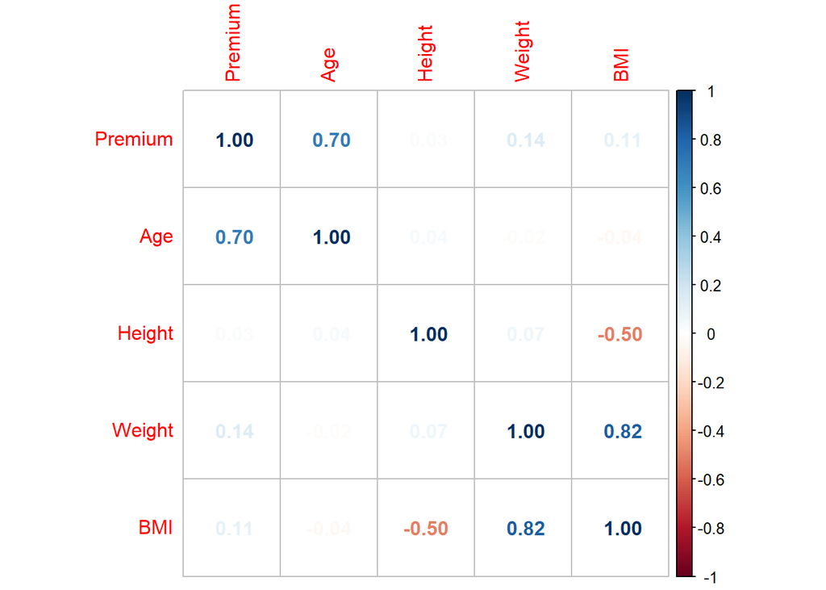

```r
premium2.dt.continuous <- subset(premium2.dt, select=c(Premium, Age, Height, Weight, BMI))

corrplot(cor(premium2.dt.continuous), method="number")
```

**Findings**  
There is high correlation between Age and Premium, suggesting that Age could be one of the most important predictors for Premium within the continuous variables.

BMI has high correlation with Weight and moderately high correlation with Height, which could result in BMI being removed in the models subsequently. This makes sense - BMI was derived from Height and Weight

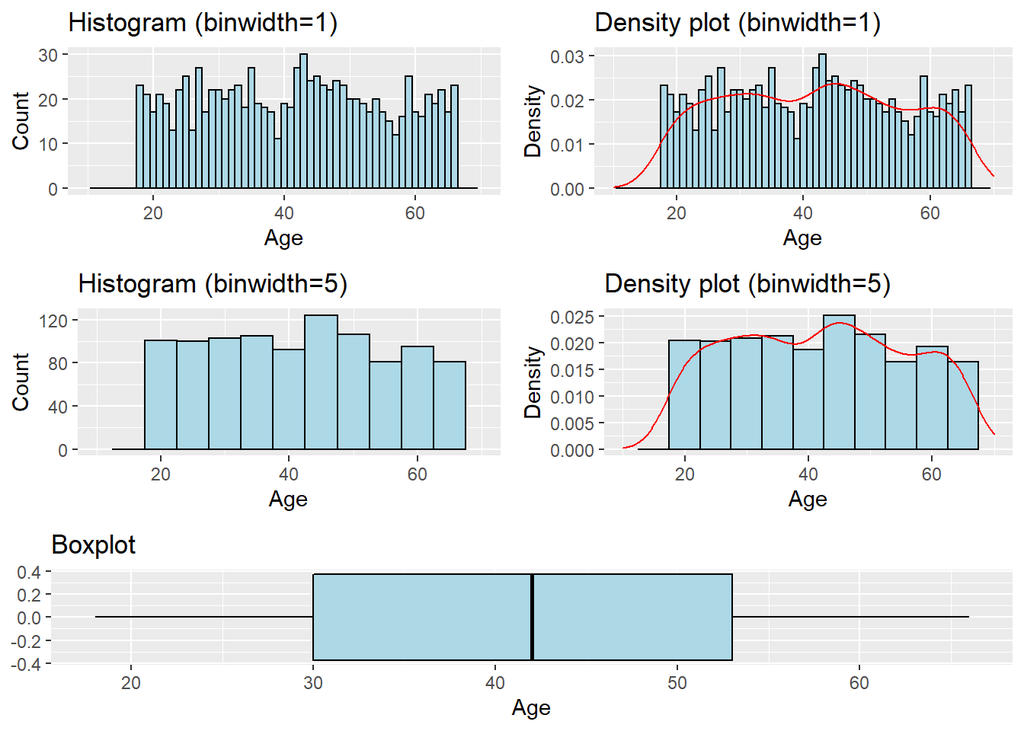

```r
plot1 <- ggplot(data=premium2.dt, aes(Age)) +
  geom_histogram(binwidth = 1, col="black", fill="lightblue") +
  labs(title="Histogram (binwidth=1)", x="Age", y="Count") +
  scale_x_continuous(limits=c(10,70))

plot2 <- ggplot(data=premium2.dt, aes(Age)) +
  geom_histogram(binwidth = 1, col="black", fill="lightblue", aes(y=..density..)) +
  geom_density(colour="red") +
  labs(title="Density plot (binwidth=1)", x="Age", y="Density") +
  scale_x_continuous(limits=c(10,70))

plot3 <- ggplot(data=premium2.dt, aes(Age)) +
  geom_histogram(binwidth = 5, col="black", fill="lightblue") +
  labs(title="Histogram (binwidth=5)", x="Age", y="Count") +
  scale_x_continuous(limits=c(10,70))

plot4 <- ggplot(data=premium2.dt, aes(Age)) +
  geom_histogram(binwidth = 5, col="black", fill="lightblue", aes(y=..density..)) +
  geom_density(colour="red") +
  labs(title="Density plot (binwidth=5)", x="Age", y="Density") +
  scale_x_continuous(limits=c(10,70))

plot5 <- ggplot(data=premium2.dt, aes(Age)) +
  geom_boxplot(col="black", fill="lightblue", outlier.shape=4) +
    labs(title="Boxplot", x="Age")

plot6 <- plot_grid(plot1, plot2, plot3, plot4, ncol=2)
plot_grid(plot6, plot5, ncol=1, rel_heights = c(5,2))
```

**Findings**  
There is a rather even distribution of age through the dataset. The only thing interesting to see is that there are slightly more people just over 40 who have bought insurance.

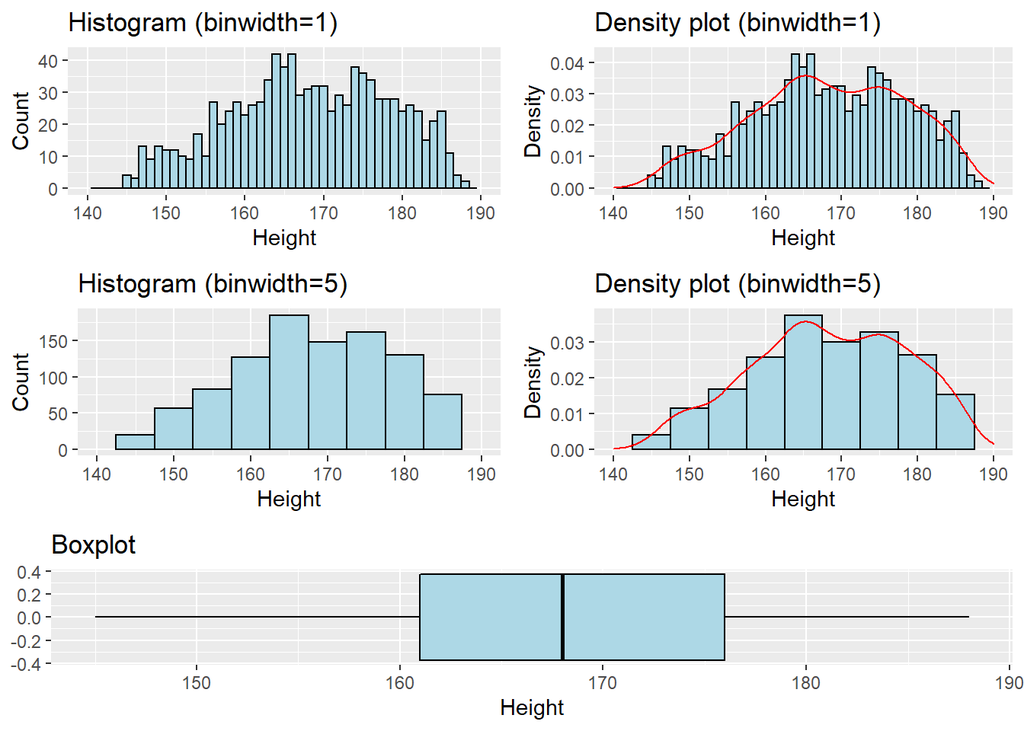

```r
plot1 <- ggplot(data=premium2.dt, aes(Height)) +
  geom_histogram(binwidth = 1, col="black", fill="lightblue") +
  labs(title="Histogram (binwidth=1)", x="Height", y="Count") +
  scale_x_continuous(limits=c(140,190))

plot2 <- ggplot(data=premium2.dt, aes(Height)) +
  geom_histogram(binwidth = 1, col="black", fill="lightblue", aes(y=..density..)) +
  geom_density(colour="red") +
  labs(title="Density plot (binwidth=1)", x="Height", y="Density") +
  scale_x_continuous(limits=c(140,190))

plot3 <- ggplot(data=premium2.dt, aes(Height)) +
  geom_histogram(binwidth = 5, col="black", fill="lightblue") +
  labs(title="Histogram (binwidth=5)", x="Height", y="Count") +
  scale_x_continuous(limits=c(140,190))

plot4 <- ggplot(data=premium2.dt, aes(Height)) +
  geom_histogram(binwidth = 5, col="black", fill="lightblue", aes(y=..density..)) +
  geom_density(colour="red") +
  labs(title="Density plot (binwidth=5)", x="Height", y="Density") +
  scale_x_continuous(limits=c(140,190))

plot5 <- ggplot(data=premium2.dt, aes(Height)) +
  geom_boxplot(col="black", fill="lightblue", outlier.shape=4) +
    labs(title="Boxplot", x="Height")

plot6 <- plot_grid(plot1, plot2, plot3, plot4, ncol=2)
plot_grid(plot6, plot5, ncol=1, rel_heights = c(5,2))
```

**Findings**  
Most of the population have a height between 160cm to 175cm

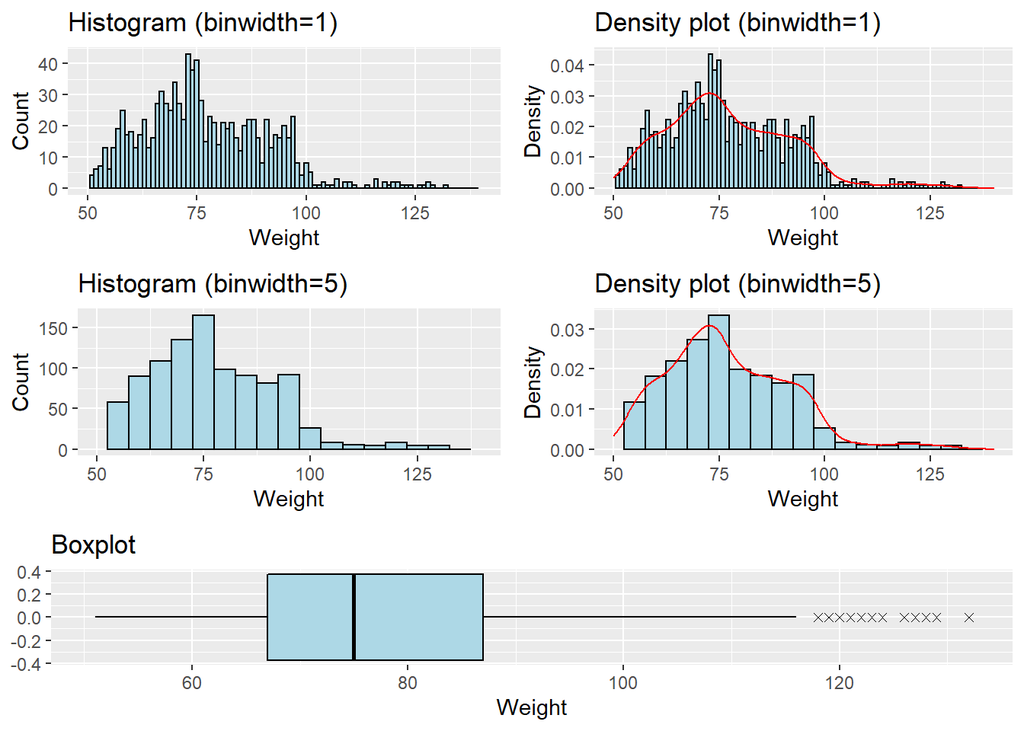

```r
plot1 <- ggplot(data=premium2.dt, aes(Weight)) +
  geom_histogram(binwidth = 1, col="black", fill="lightblue") +
  labs(title="Histogram (binwidth=1)", x="Weight", y="Count") +
  scale_x_continuous(limits=c(50,140))

plot2 <- ggplot(data=premium2.dt, aes(Weight)) +
  geom_histogram(binwidth = 1, col="black", fill="lightblue", aes(y=..density..)) +
  geom_density(colour="red") +
  labs(title="Density plot (binwidth=1)", x="Weight", y="Density") +
  scale_x_continuous(limits=c(50,140))

plot3 <- ggplot(data=premium2.dt, aes(Weight)) +
  geom_histogram(binwidth = 5, col="black", fill="lightblue") +
  labs(title="Histogram (binwidth=5)", x="Weight", y="Count") +
  scale_x_continuous(limits=c(50,140))

plot4 <- ggplot(data=premium2.dt, aes(Weight)) +
  geom_histogram(binwidth = 5, col="black", fill="lightblue", aes(y=..density..)) +
  geom_density(colour="red") +
  labs(title="Density plot (binwidth=5)", x="Weight", y="Density") +
  scale_x_continuous(limits=c(50,140))

plot5 <- ggplot(data=premium2.dt, aes(Weight)) +
  geom_boxplot(col="black", fill="lightblue", outlier.shape=4) +
    labs(title="Boxplot", x="Weight")

plot6 <- plot_grid(plot1, plot2, plot3, plot4, ncol=2)
plot_grid(plot6, plot5, ncol=1, rel_heights = c(5,2))
```

**Findings**  
Most of the population has a weight around 75kg, but there is a significant number of outliers that are in the 120kg range (which is concerning)

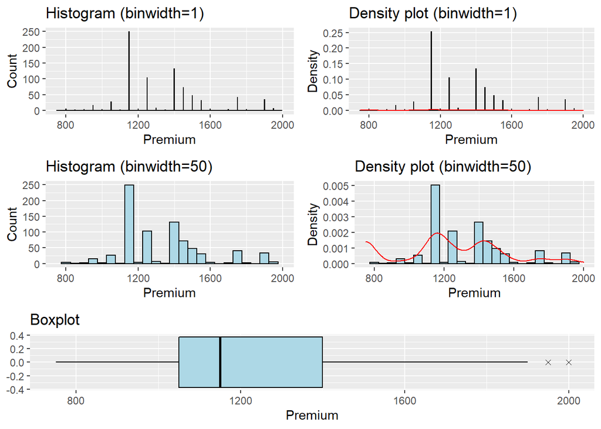

```r
plot1 <- ggplot(data=premium2.dt, aes(Premium)) +
  geom_histogram(binwidth = 1, col="black", fill="lightblue") +
  labs(title="Histogram (binwidth=1)", x="Premium", y="Count") +
  scale_x_continuous(limits=c(750,2000))

plot2 <- ggplot(data=premium2.dt, aes(Premium)) +
  geom_histogram(binwidth = 1, col="black", fill="lightblue", aes(y=..density..)) +
  geom_density(colour="red") +
  labs(title="Density plot (binwidth=1)", x="Premium", y="Density") +
  scale_x_continuous(limits=c(750,2000))

plot3 <- ggplot(data=premium2.dt, aes(Premium)) +
  geom_histogram(binwidth = 50, col="black", fill="lightblue") +
  labs(title="Histogram (binwidth=50)", x="Premium", y="Count") +
  scale_x_continuous(limits=c(750,2000))

plot4 <- ggplot(data=premium2.dt, aes(Premium)) +
  geom_histogram(binwidth = 50, col="black", fill="lightblue", aes(y=..density..)) +
  geom_density(colour="red") +
  labs(title="Density plot (binwidth=50)", x="Premium", y="Density") +
  scale_x_continuous(limits=c(750,2000))

plot5 <- ggplot(data=premium2.dt, aes(Premium)) +
  geom_boxplot(col="black", fill="lightblue", outlier.shape=4) +
    labs(title="Boxplot", x="Premium")

plot6 <- plot_grid(plot1, plot2, plot3, plot4, ncol=2)
plot_grid(plot6, plot5, ncol=1, rel_heights = c(5,2))
```

```r
uniqueN(premium2.dt$Premium)
```

```
## [1] 24
```

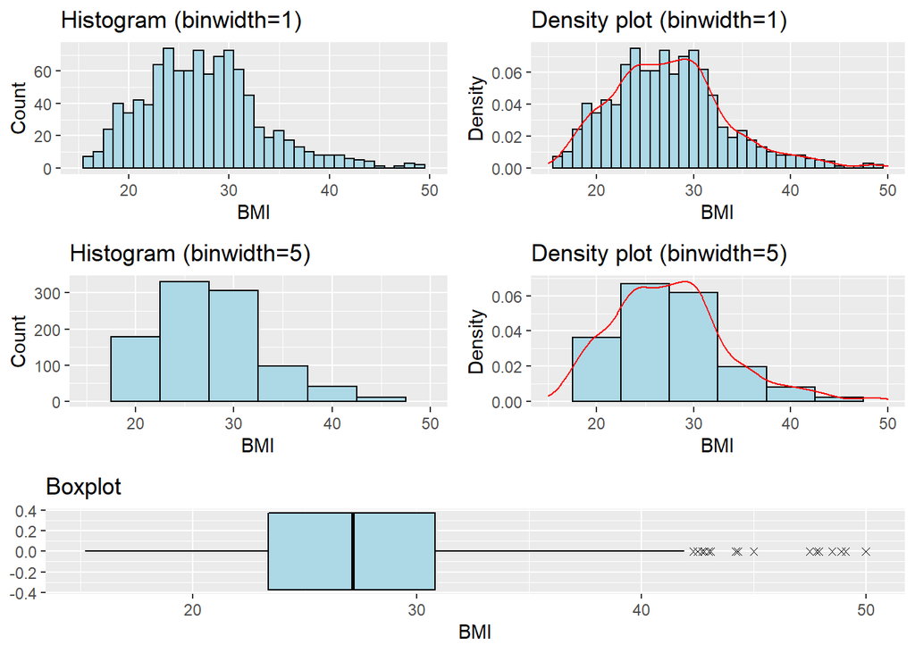

```r
plot1 <- ggplot(data=premium2.dt, aes(BMI)) +
  geom_histogram(binwidth = 1, col="black", fill="lightblue") +
  labs(title="Histogram (binwidth=1)", x="BMI", y="Count") +
  scale_x_continuous(limits=c(15,50))

plot2 <- ggplot(data=premium2.dt, aes(BMI)) +
  geom_histogram(binwidth = 1, col="black", fill="lightblue", aes(y=..density..)) +
  geom_density(colour="red") +
  labs(title="Density plot (binwidth=1)", x="BMI", y="Density") +
  scale_x_continuous(limits=c(15,50))

plot3 <- ggplot(data=premium2.dt, aes(BMI)) +
  geom_histogram(binwidth = 5, col="black", fill="lightblue") +
  labs(title="Histogram (binwidth=5)", x="BMI", y="Count") +
  scale_x_continuous(limits=c(15,50))

plot4 <- ggplot(data=premium2.dt, aes(BMI)) +
  geom_histogram(binwidth = 5, col="black", fill="lightblue", aes(y=..density..)) +
  geom_density(colour="red") +
  labs(title="Density plot (binwidth=5)", x="BMI", y="Density") +
  scale_x_continuous(limits=c(15,50))

plot5 <- ggplot(data=premium2.dt, aes(BMI)) +
  geom_boxplot(col="black", fill="lightblue", outlier.shape=4) +
  labs(title="Boxplot", x="BMI")

plot6 <- plot_grid(plot1, plot2, plot3, plot4, ncol=2)
plot_grid(plot6, plot5, ncol=1, rel_heights = c(5,2))
```

**Findings**  
Most of the population has a BMI between 25 to 30. According to the CDC, this means most of the population is overweight. There are also several outliers who are obese

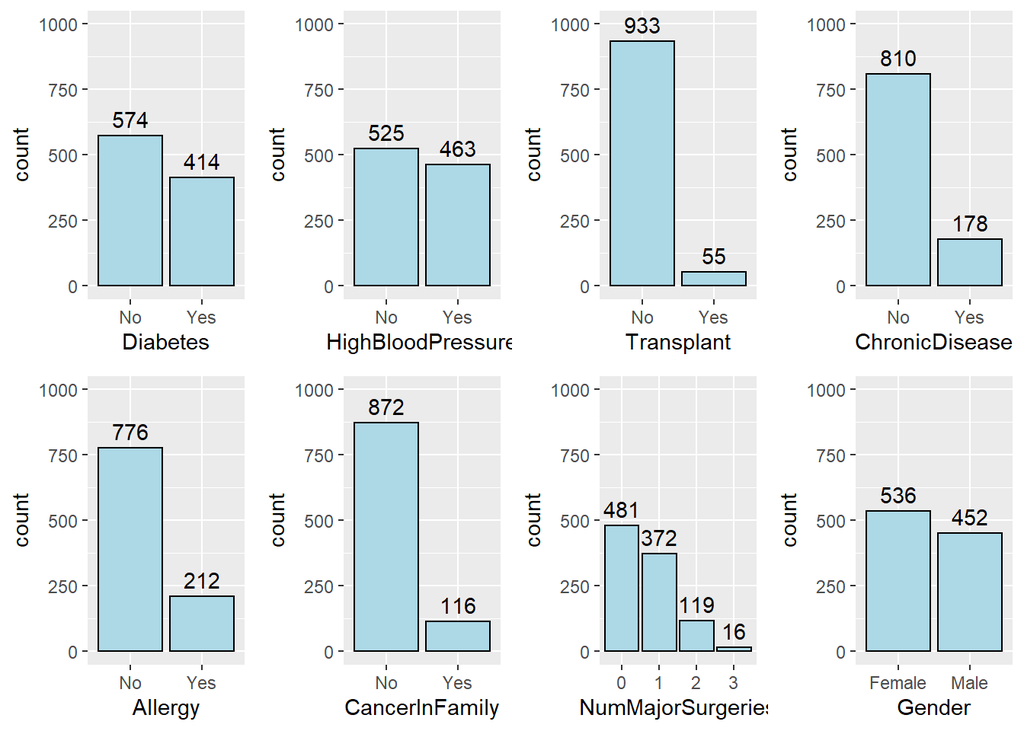

```r
plot1 <- ggplot(data=premium2.dt, aes(Diabetes)) +
  geom_bar(col="black", fill="lightblue") +
  geom_text(stat='Count', aes(label=..count..), vjust=-0.5) +
  scale_y_continuous(limits=c(0,1000))

plot2 <- ggplot(data=premium2.dt, aes(HighBloodPressure)) +
  geom_bar(col="black", fill="lightblue") +
  geom_text(stat='Count', aes(label=..count..), vjust=-0.5) +
  scale_y_continuous(limits=c(0,1000))

plot3 <- ggplot(data=premium2.dt, aes(Transplant)) +
  geom_bar(col="black", fill="lightblue") +
  geom_text(stat='Count', aes(label=..count..), vjust=-0.5) +
  scale_y_continuous(limits=c(0,1000))

plot4 <- ggplot(data=premium2.dt, aes(ChronicDisease)) +
  geom_bar(col="black", fill="lightblue") +
  geom_text(stat='Count', aes(label=..count..), vjust=-0.5) +
  scale_y_continuous(limits=c(0,1000))

plot5 <- ggplot(data=premium2.dt, aes(Allergy)) +
  geom_bar(col="black", fill="lightblue") +
  geom_text(stat='Count', aes(label=..count..), vjust=-0.5) +
  scale_y_continuous(limits=c(0,1000))

plot6 <- ggplot(data=premium2.dt, aes(CancerInFamily)) +
  geom_bar(col="black", fill="lightblue") +
  geom_text(stat='Count', aes(label=..count..), vjust=-0.5) +
  scale_y_continuous(limits=c(0,1000))

plot7 <- ggplot(data=premium2.dt, aes(NumMajorSurgeries)) +
  geom_bar(col="black", fill="lightblue") +
  geom_text(stat='Count', aes(label=..count..), vjust=-0.5) +
  scale_y_continuous(limits=c(0,1000))

plot8 <- ggplot(data=premium2.dt, aes(Gender)) +
  geom_bar(col="black", fill="lightblue") +
  geom_text(stat='Count', aes(label=..count..), vjust=-0.5) +
  scale_y_continuous(limits=c(0,1000))

plot_grid(plot1, plot2, plot3, plot4, plot5, plot6, plot7, plot8, ncol=4)
```

**Findings**  
Simply a count plot.

### Data exploration against Premium

It is possible to do a pairwise plot for every single variable against every other variable. However, since we have 13 variables, this will lead to (13^2-13)/2 = 78 different graphs to analyze, which is too much.

Therefore, we will limit our exploration to just independent variables vs dependent variable. That is, all variables plotted against the dependent variable of Premium. This will result in only 12 plots to analyze

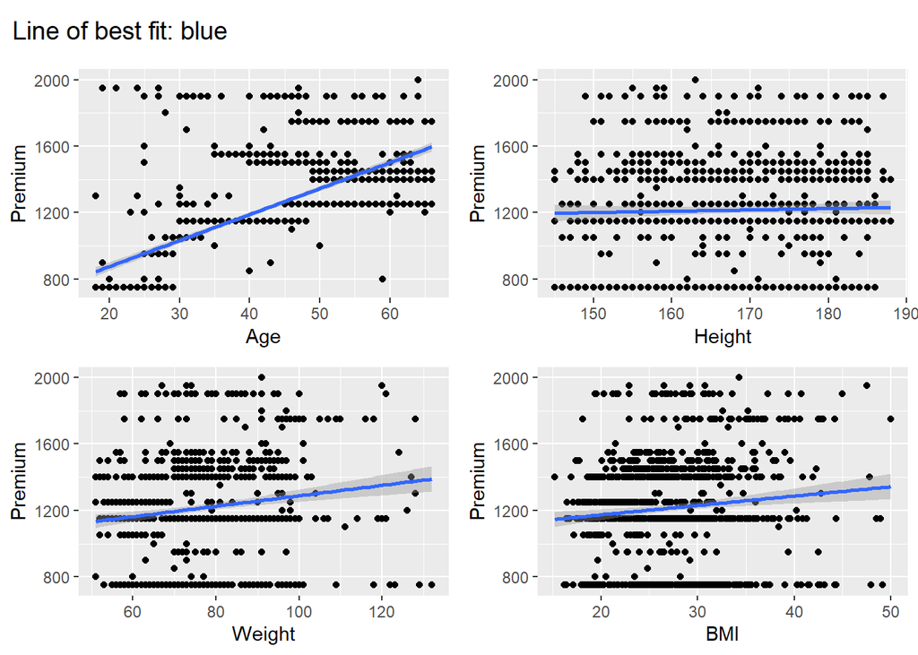

```r
# scatterplots for continuous variables
plot1 <- ggplot(data=premium2.dt, aes(Age, Premium)) +
  geom_point(colour="black") +
  geom_smooth(method='lm', formula= y~x)


plot2 <- ggplot(data=premium2.dt, aes(Height, Premium)) +
  geom_point(colour="black") +
  geom_smooth(method='lm', formula= y~x)

plot3 <- ggplot(data=premium2.dt, aes(Weight, Premium)) +
  geom_point(colour="black") +
  geom_smooth(method='lm', formula= y~x)

plot4 <- ggplot(data=premium2.dt, aes(BMI, Premium)) +
  geom_point(colour="black") +
  geom_smooth(method='lm', formula= y~x)

title <- ggdraw() +
  draw_label("Line of best fit: blue", x = 0, hjust = 0) +
  theme(plot.margin = margin(0, 0, 0, 7))

plot_row <- plot_grid(plot1, plot2, plot3, plot4, ncol=2)
plot_grid(title, plot_row, ncol = 1, rel_heights = c(0.1, 1))
```

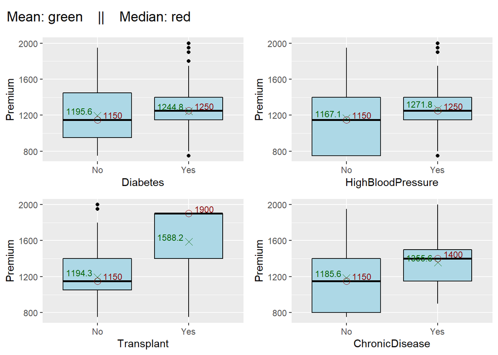

```r
# boxplots for factor variables
plot5 <- ggplot(data=premium2.dt, aes(Diabetes, Premium)) +
  geom_boxplot(colour="black", fill="lightblue") +
  stat_summary(fun=mean, colour="darkgreen", geom="point", size=3, shape=4) +
  stat_summary(fun=mean, colour="darkgreen", geom="text", vjust=-0.2,
               hjust=1.2, aes( label=round(..y.., digits=1)), size=3) +
  stat_summary(fun=median, colour="darkred", geom="point", size=3, shape=1) +
  stat_summary(fun=median, colour="darkred", geom="text", vjust=-0.2,
               hjust=-0.3, aes( label=round(..y.., digits=1)), size=3)

plot6 <- ggplot(data=premium2.dt, aes(HighBloodPressure, Premium)) +
  geom_boxplot(colour="black", fill="lightblue") +
  stat_summary(fun=mean, colour="darkgreen", geom="point", size=3, shape=4) +
  stat_summary(fun=mean, colour="darkgreen", geom="text", vjust=-0.2,
               hjust=1.2, aes( label=round(..y.., digits=1)), size=3) +
  stat_summary(fun=median, colour="darkred", geom="point", size=3, shape=1) +
  stat_summary(fun=median, colour="darkred", geom="text", vjust=-0.2,
               hjust=-0.3, aes( label=round(..y.., digits=1)), size=3)

plot7 <- ggplot(data=premium2.dt, aes(Transplant, Premium)) +
  geom_boxplot(colour="black", fill="lightblue") +
  stat_summary(fun=mean, colour="darkgreen", geom="point", size=3, shape=4) +
  stat_summary(fun=mean, colour="darkgreen", geom="text", vjust=-0.2,
               hjust=1.2, aes( label=round(..y.., digits=1)), size=3) +
  stat_summary(fun=median, colour="darkred", geom="point", size=3, shape=1) +
  stat_summary(fun=median, colour="darkred", geom="text", vjust=-0.2,
               hjust=-0.3, aes( label=round(..y.., digits=1)), size=3)

plot8 <- ggplot(data=premium2.dt, aes(ChronicDisease, Premium)) +
  geom_boxplot(colour="black", fill="lightblue") +
  stat_summary(fun=mean, colour="darkgreen", geom="point", size=3, shape=4) +
  stat_summary(fun=mean, colour="darkgreen", geom="text", vjust=-0.2,
               hjust=1.2, aes( label=round(..y.., digits=1)), size=3) +
  stat_summary(fun=median, colour="darkred", geom="point", size=3, shape=1) +
  stat_summary(fun=median, colour="darkred", geom="text", vjust=-0.2,
               hjust=-0.3, aes( label=round(..y.., digits=1)), size=3)

plot9 <- ggplot(data=premium2.dt, aes(Allergy, Premium)) +
  geom_boxplot(colour="black", fill="lightblue") +
  stat_summary(fun=mean, colour="darkgreen", geom="point", size=3, shape=4) +
  stat_summary(fun=mean, colour="darkgreen", geom="text", vjust=-0.2,
               hjust=1.2, aes( label=round(..y.., digits=1)), size=3) +
  stat_summary(fun=median, colour="darkred", geom="point", size=3, shape=1) +
  stat_summary(fun=median, colour="darkred", geom="text", vjust=-0.2,
               hjust=-0.3, aes( label=round(..y.., digits=1)), size=3)

plot10 <- ggplot(data=premium2.dt, aes(CancerInFamily, Premium)) +
  geom_boxplot(colour="black", fill="lightblue") +
  stat_summary(fun=mean, colour="darkgreen", geom="point", size=3, shape=4) +
  stat_summary(fun=mean, colour="darkgreen", geom="text", vjust=-0.2,
               hjust=1.2, aes( label=round(..y.., digits=1)), size=3) +
  stat_summary(fun=median, colour="darkred", geom="point", size=3, shape=1) +
  stat_summary(fun=median, colour="darkred", geom="text", vjust=-0.2,
               hjust=-0.3, aes( label=round(..y.., digits=1)), size=3)

plot11 <- ggplot(data=premium2.dt, aes(NumMajorSurgeries, Premium)) +
  geom_boxplot(colour="black", fill="lightblue") +
  stat_summary(fun=mean, colour="darkgreen", geom="point", size=3, shape=4) +
  stat_summary(fun=mean, colour="darkgreen", geom="text", vjust=-0.2,
               hjust=1.2, aes( label=round(..y.., digits=1)), size=3) +
  stat_summary(fun=median, colour="darkred", geom="point", size=3, shape=1) +
  stat_summary(fun=median, colour="darkred", geom="text", vjust=-0.2,
               hjust=-0.3, aes( label=round(..y.., digits=1)), size=3)

plot12 <- ggplot(data=premium2.dt, aes(Gender, Premium)) +
  geom_boxplot(colour="black", fill="lightblue") +
  stat_summary(fun=mean, colour="darkgreen", geom="point", size=3, shape=4) +
  stat_summary(fun=mean, colour="darkgreen", geom="text", vjust=-0.2,
               hjust=1.2, aes( label=round(..y.., digits=1)),size=3) +
  stat_summary(fun=median, colour="darkred", geom="point", size=3, shape=1) +
  stat_summary(fun=median, colour="darkred", geom="text", vjust=-0.2,
               hjust=-0.3, aes( label=round(..y.., digits=1)), size=3)


title <- ggdraw() +
  draw_label("Mean: green    ||    Median: red", x = 0, hjust = 0) +
  theme(plot.margin = margin(0, 0, 0, 7))

plot_row <- plot_grid(plot5, plot6, plot7, plot8, ncol=2)
plot_grid(title, plot_row, ncol = 1, rel_heights = c(0.1, 1))
```

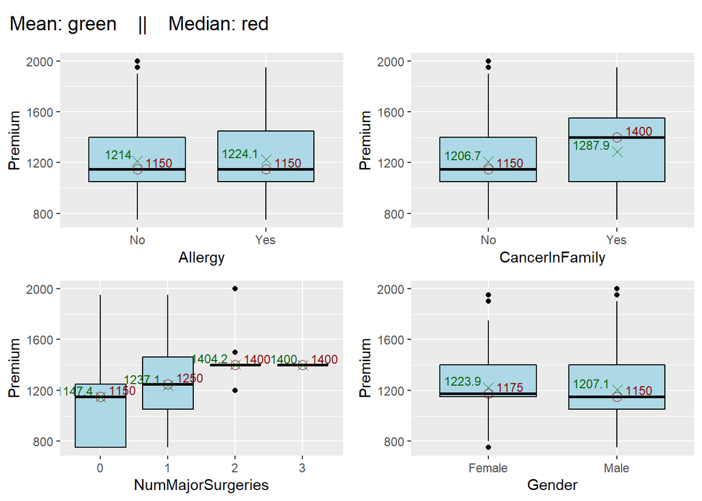

```r
plot_row <- plot_grid(plot9, plot10, plot11, plot12, ncol=2)
plot_grid(title, plot_row, ncol = 1, rel_heights = c(0.1, 1))
```

Using 1 SE optimal CART and one other technique learnt in this course: a. What is the 10-fold cross validation RMSE and number of splits in the 1SE Optimal CART? b. Identify the key predictors of premium. c. Is BMI or Gender important in determining premium? d. Evaluate and compare the predictive accuracy of the two techniques on a 70-30 train-test split. Present testset RMSE results in a table

The other technique that we shall employ will be linear regression. We shall answer the questions 4a using linear regression

### CART

We shall follow the procedure outlined in the lecture notes for CART in RE6013. It should be noted that CART is immune to issues of multicollinearity, hence BMI variable does not need to be removed beforehand

```r
# create the cart model that will grow a maximum tree. use the trainset as the data
cart1 <- rpart(Premium ~ ., data = premium2.dt, method = 'anova', control = rpart.control(minsplit = 2, cp = 0))

# check the cp values to select the minimum cp value
printcp(cart1, digits = 3)
```

```
##
## Regression tree:
## rpart(formula = Premium ~ ., data = premium2.dt, method = "anova",
##     control = rpart.control(minsplit = 2, cp = 0))
##
## Variables actually used in tree construction:
##  [1] Age               Allergy           BMI               CancerInFamily
##  [5] ChronicDisease    Diabetes          Gender            Height
##  [9] HighBloodPressure NumMajorSurgeries Transplant        Weight
##
## Root node error: 96355891/988 = 97526
##
## n= 988
##
##          CP nsplit rel error xerror   xstd
```

[output cut: 75 more lines]

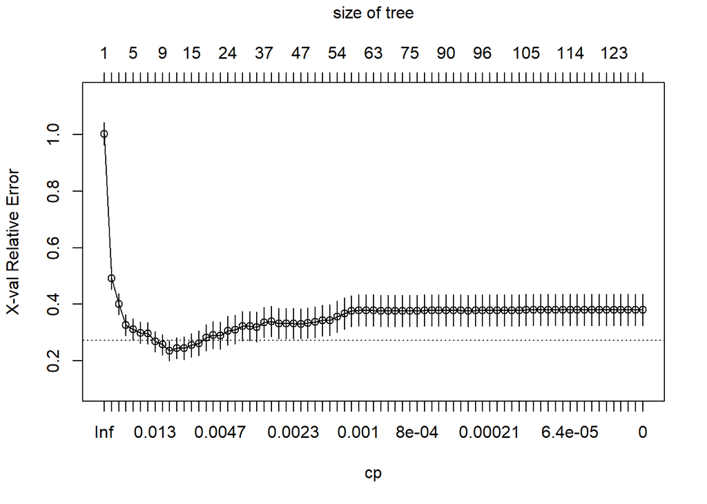

```r
plotcp(cart1)
```

```r
# min cp + 1 stddev
CVerror.cap <- cart1$cptable[which.min(cart1$cptable[,"xerror"]), "xerror"] +  cart1$cptable[which.min(cart1$cptable[,"xerror"]), "xstd"]

# Find the optimal CP region whose CV error is just below CVerror.cap in maximal tree cart1.
i <- 1; j<- 4
while (cart1$cptable[i,j] > CVerror.cap) {
  i <- i + 1
}
cp1 = ifelse(i > 1, sqrt(cart1$cptable[i,1] * cart1$cptable[i-1,1]), 1)
```

```r
# create the next cart model, which is the optimal tree
cart2 <- prune(cart1, cp = cp1)
printcp(cart2, digits = 3)
```

```
##
## Regression tree:
## rpart(formula = Premium ~ ., data = premium2.dt, method = "anova",
##     control = rpart.control(minsplit = 2, cp = 0))
##
## Variables actually used in tree construction:
## [1] Age               CancerInFamily    ChronicDisease    NumMajorSurgeries
## [5] Transplant        Weight
##
## Root node error: 96355891/988 = 97526
##
## n= 988
##
##       CP nsplit rel error xerror   xstd
## 1 0.5110      0     1.000  1.003 0.0397
## 2 0.0907      1     0.489  0.491 0.0393
## 3 0.0746      2     0.398  0.401 0.0376
## 4 0.0253      3     0.324  0.327 0.0373
## 5 0.0185      4     0.298  0.311 0.0372
## 6 0.0180      5     0.280  0.299 0.0377
## 7 0.0135      6     0.262  0.297 0.0384
## 8 0.0135      7     0.248  0.268 0.0364
```

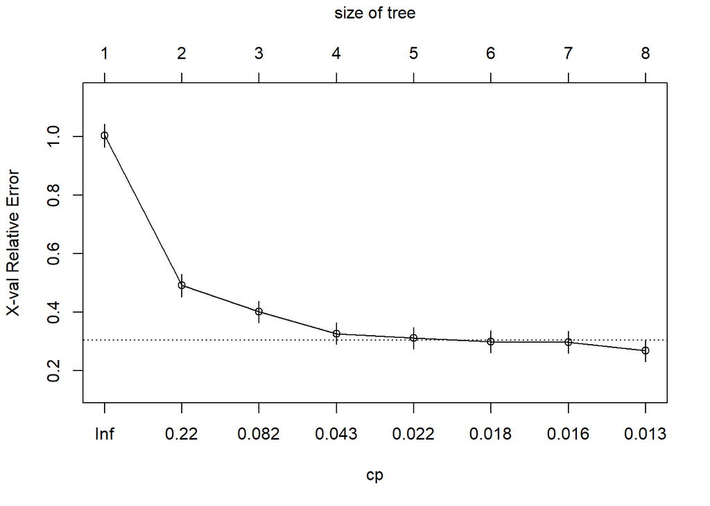

```r
plotcp(cart2)
```

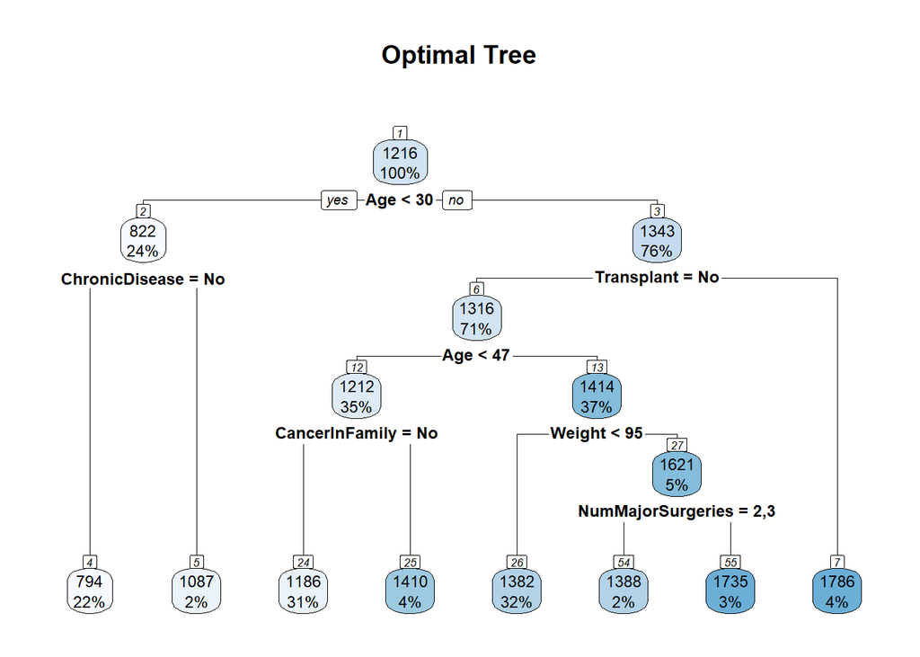

```r
# plot the optimal tree
rpart.plot(cart2, nn = T, main = "Optimal Tree")
```

```r
## The number inside each node represent the mean value of Y.

# check the variable importance
cart2$variable.importance
```

```
##               Age        Transplant NumMajorSurgeries            Weight
##          56591531           8735453           3514205           3373486
##    ChronicDisease    CancerInFamily               BMI HighBloodPressure
##           1784659           1733030           1349207           1096521
##          Diabetes
##           1012173
```

```r
summary(cart2)
```

```
## Call:
## rpart(formula = Premium ~ ., data = premium2.dt, method = "anova",
##     control = rpart.control(minsplit = 2, cp = 0))
##   n= 988
##
##           CP nsplit rel error    xerror       xstd
## 1 0.51100533      0 1.0000000 1.0032600 0.03966197
## 2 0.09065822      1 0.4889947 0.4911337 0.03925018
## 3 0.07462593      2 0.3983365 0.4008493 0.03755458
## 4 0.02531330      3 0.3237105 0.3266308 0.03726187
## 5 0.01852154      4 0.2983972 0.3113655 0.03719648
## 6 0.01798571      5 0.2798757 0.2987942 0.03774266
## 7 0.01349244      6 0.2618900 0.2969342 0.03840094
## 8 0.01345653      7 0.2483975 0.2676059 0.03639179
##
## Variable importance
##               Age        Transplant NumMajorSurgeries            Weight
##                71                11                 4                 4
##    ChronicDisease    CancerInFamily               BMI HighBloodPressure
##                 2                 2                 2                 1
##          Diabetes
##                 1
##
## Node number 1: 988 observations,    complexity param=0.5110053
##   mean=1216.194, MSE=97526.21
##   left son=2 (240 obs) right son=3 (748 obs)
##   Primary splits:
##       Age               < 29.5  to the left,  improve=0.51100530, (0 missing)
##       Transplant        splits as  LR,        improve=0.08364045, (0 missing)
##       NumMajorSurgeries splits as  LLRR,      improve=0.05705706, (0 missing)
##       ChronicDisease    splits as  LR,        improve=0.04380125, (0 missing)
##       HighBloodPressure splits as  LR,        improve=0.02797442, (0 missing)
##   Surrogate splits:
##       Weight < 127.5 to the right, agree=0.759, adj=0.008, (0 split)
##
## Node number 2: 240 observations,    complexity param=0.01852154
##   mean=822.0833, MSE=50408.16
##   left son=4 (217 obs) right son=5 (23 obs)
##   Primary splits:
##       ChronicDisease    splits as  LR,        improve=0.14751740, (0 missing)
```

[output cut: 75 more lines]

```
##       NumMajorSurgeries splits as  RRLL,      improve=0.79515340, (0 missing)
##       Age               < 59    to the right, improve=0.13504980, (0 missing)
##       HighBloodPressure splits as  RL,        improve=0.06581251, (0 missing)
##       Weight            < 99.5  to the left,  improve=0.06167176, (0 missing)
##       Height            < 174.5 to the right, improve=0.05667611, (0 missing)
##   Surrogate splits:
##       Age    < 61.5  to the right, agree=0.714, adj=0.125, (0 split)
##       Weight < 122   to the right, agree=0.694, adj=0.063, (0 split)
##       BMI    < 31.15 to the left,  agree=0.694, adj=0.063, (0 split)
##
## Node number 54: 16 observations
##   mean=1387.5, MSE=2343.75
##
## Node number 55: 33 observations
##   mean=1734.848, MSE=9012.856
```

```r
# calculate errors from inspecting the printcp table
cart2_root_node_error <- 97526 # copy from cp table
cart2_xerror <- 0.268 # take the very last value of xerror from cp table
cart2_cv_rmse <- sqrt(cart2_xerror * cart2_root_node_error)
cart2_cv_rmse
```

```
## [1] 161.6693
```

### Linreg

We shall follow the procedure outlined in the lecture notes for linear regression in RE6013

```r
# create a linear regression model on trainset, with all the variables
linreg1 <- lm(Premium ~ ., data = premium2.dt)
summary(linreg1)
```

```
##
## Call:
## lm(formula = Premium ~ ., data = premium2.dt)
##
## Residuals:
##     Min      1Q  Median      3Q     Max
## -668.64 -106.07  -15.68   95.92 1181.48
##
## Coefficients:
##                       Estimate Std. Error t value Pr(>|t|)
## (Intercept)           607.2423   530.9069   1.144 0.252995
## Age                    16.7954     0.4981  33.721  < 2e-16 ***
## DiabetesYes           -15.8571    12.5914  -1.259 0.208203
## HighBloodPressureYes    3.7223    12.7566   0.292 0.770508
## TransplantYes         392.6658    25.9663  15.122  < 2e-16 ***
## ChronicDiseaseYes     132.7307    15.6562   8.478  < 2e-16 ***
## Height                 -2.4211     3.1356  -0.772 0.440212
## Weight                  5.8193     3.3541   1.735 0.083056 .
## AllergyYes             -1.7246    15.3960  -0.112 0.910835
## CancerInFamilyYes      92.4751    20.2162   4.574 5.39e-06 ***
## NumMajorSurgeries1     11.6387    15.1085   0.770 0.441285
## NumMajorSurgeries2    -83.2121    21.8938  -3.801 0.000153 ***
## NumMajorSurgeries3   -155.9579    49.5694  -3.146 0.001704 **
## GenderMale             -2.5717    12.0038  -0.214 0.830407
## BMI                    -6.3471     9.4116  -0.674 0.500221
## ---
## Signif. codes:  0 '***' 0.001 '**' 0.01 '*' 0.05 '.' 0.1 ' ' 1
##
## Residual standard error: 186.5 on 973 degrees of freedom
## Multiple R-squared:  0.6488, Adjusted R-squared:  0.6438
## F-statistic: 128.4 on 14 and 973 DF,  p-value: < 2.2e-16
```

```r
vif(linreg1)
```

```
##                        GVIF Df GVIF^(1/(2*Df))
## Age                1.372259  1        1.171434
## Diabetes           1.096465  1        1.047122
## HighBloodPressure  1.151188  1        1.072934
## Transplant         1.006938  1        1.003463
## ChronicDisease     1.028529  1        1.014164
## Height            28.410893  1        5.330187
## Weight            64.975395  1        8.060732
## Allergy            1.134882  1        1.065308
## CancerInFamily     1.203119  1        1.096868
## NumMajorSurgeries  1.895449  3        1.112462
## Gender             1.015969  1        1.007953
## BMI               86.945996  1        9.324484
```

```r
# we can observe that the GVIF value of BMI is extremely high. this is to be expected because BMI is derived from Height and Weight, therefore multicollinearity is bound to be high. we should be removing BMI from our analysis since it has the highest GVIF=87 > 2

# remove BMI which has the highest GVIF
linreg2 <- lm(Premium ~ .-BMI, data = premium2.dt)
summary(linreg2)
```

```
##
## Call:
## lm(formula = Premium ~ . - BMI, data = premium2.dt)
##
## Residuals:
##     Min      1Q  Median      3Q     Max
## -666.78 -106.89  -15.28   94.45 1182.48
##
## Coefficients:
##                       Estimate Std. Error t value Pr(>|t|)
## (Intercept)           256.2384   104.7065   2.447 0.014573 *
## Age                    16.7976     0.4979  33.735  < 2e-16 ***
## DiabetesYes           -15.6812    12.5851  -1.246 0.213060
## HighBloodPressureYes    4.2351    12.7303   0.333 0.739450
## TransplantYes         392.0551    25.9433  15.112  < 2e-16 ***
## ChronicDiseaseYes     132.9083    15.6496   8.493  < 2e-16 ***
## Height                 -0.3447     0.5928  -0.581 0.561061
## Weight                  3.5751     0.4190   8.532  < 2e-16 ***
## AllergyYes             -1.8099    15.3912  -0.118 0.906416
## CancerInFamilyYes      91.9190    20.1937   4.552 5.99e-06 ***
## NumMajorSurgeries1     11.5348    15.1035   0.764 0.445221
## NumMajorSurgeries2    -83.2669    21.8875  -3.804 0.000151 ***
## NumMajorSurgeries3   -155.4802    49.5504  -3.138 0.001753 **
## GenderMale             -2.7948    11.9959  -0.233 0.815828
## ---
## Signif. codes:  0 '***' 0.001 '**' 0.01 '*' 0.05 '.' 0.1 ' ' 1
##
## Residual standard error: 186.4 on 974 degrees of freedom
## Multiple R-squared:  0.6486, Adjusted R-squared:  0.644
## F-statistic: 138.3 on 13 and 974 DF,  p-value: < 2.2e-16
```

```r
vif(linreg2)
```

```
##                       GVIF Df GVIF^(1/(2*Df))
## Age               1.372200  1        1.171409
## Diabetes          1.095995  1        1.046898
## HighBloodPressure 1.147097  1        1.071026
## Transplant        1.005713  1        1.002852
## ChronicDisease    1.028238  1        1.014021
## Height            1.015975  1        1.007956
## Weight            1.014596  1        1.007272
## Allergy           1.134805  1        1.065272
## CancerInFamily    1.201117  1        1.095955
## NumMajorSurgeries 1.894790  3        1.112398
## Gender            1.015197  1        1.007570
```

```r
# now, all GVIF values are <2 so we will not encounter multicollinearity anymore
# we also observe that there are 6 variables that are show a relatively high level of statistical significance - Age, Transplant, ChronicDisease, CancerInFamily, Weight, NumMajorSurgeries
```

```r
# perform a stepwise search for the optimal linear regression model
linreg3 <- step(linreg2)
```

```
## Start:  AIC=10344.61
## Premium ~ (Age + Diabetes + HighBloodPressure + Transplant +
##     ChronicDisease + Height + Weight + Allergy + CancerInFamily +
##     NumMajorSurgeries + Gender + BMI) - BMI
##
##                     Df Sum of Sq      RSS   AIC
## - Allergy            1       481 33855428 10343
## - Gender             1      1887 33856834 10343
## - HighBloodPressure  1      3847 33858795 10343
## - Height             1     11752 33866700 10343
## - Diabetes           1     53964 33908912 10344
## <none>                           33854948 10345
## - CancerInFamily     1    720183 34575131 10363
## - NumMajorSurgeries  3    908239 34763186 10365
## - ChronicDisease     1   2507026 36361973 10413
## - Weight             1   2530441 36385389 10414
## - Transplant         1   7937936 41792884 10551
## - Age                1  39557551 73412499 11107
##
## Step:  AIC=10342.62
## Premium ~ Age + Diabetes + HighBloodPressure + Transplant + ChronicDisease +
##     Height + Weight + CancerInFamily + NumMajorSurgeries + Gender
##
##                     Df Sum of Sq      RSS   AIC
## - Gender             1      1893 33857322 10341
## - HighBloodPressure  1      3994 33859422 10341
## - Height             1     11657 33867086 10341
## - Diabetes           1     53660 33909088 10342
## <none>                           33855428 10343
## - CancerInFamily     1    721190 34576619 10361
## - NumMajorSurgeries  3    922534 34777962 10363
## - ChronicDisease     1   2511502 36366930 10411
## - Weight             1   2533141 36388569 10412
## - Transplant         1   7939299 41794727 10549
## - Age                1  39560351 73415779 11105
##
## Step:  AIC=10340.68
## Premium ~ Age + Diabetes + HighBloodPressure + Transplant + ChronicDisease +
##     Height + Weight + CancerInFamily + NumMajorSurgeries
##
```

[output cut: 38 more lines]

```
## - Transplant         1   7967309 41840401 10544
## - Age                1  40679725 74552817 11115
##
## Step:  AIC=10336.64
## Premium ~ Age + Transplant + ChronicDisease + Weight + CancerInFamily +
##     NumMajorSurgeries
##
##                     Df Sum of Sq      RSS   AIC
## <none>                           33924577 10337
## - CancerInFamily     1    725343 34649920 10356
## - NumMajorSurgeries  3    997819 34922396 10359
## - Weight             1   2538530 36463107 10406
## - ChronicDisease     1   2606162 36530739 10408
## - Transplant         1   8013166 41937743 10544
## - Age                1  41151014 75075591 11120
```

```r
summary(linreg3)
```

```
##
## Call:
## lm(formula = Premium ~ Age + Transplant + ChronicDisease + Weight +
##     CancerInFamily + NumMajorSurgeries, data = premium2.dt)
##
## Residuals:
##     Min      1Q  Median      3Q     Max
## -657.10 -109.02  -13.45   96.87 1185.54
##
## Coefficients:
##                     Estimate Std. Error t value Pr(>|t|)
## (Intercept)         195.2795    38.4173   5.083 4.45e-07 ***
## Age                  16.7306     0.4855  34.461  < 2e-16 ***
## TransplantYes       393.3761    25.8685  15.207  < 2e-16 ***
## ChronicDiseaseYes   134.3662    15.4937   8.672  < 2e-16 ***
## Weight                3.5603     0.4160   8.559  < 2e-16 ***
## CancerInFamilyYes    92.2126    20.1551   4.575 5.37e-06 ***
## NumMajorSurgeries1   12.7562    14.1536   0.901 0.367665
## NumMajorSurgeries2  -83.6129    21.4483  -3.898 0.000103 ***
## NumMajorSurgeries3 -163.0772    49.0348  -3.326 0.000915 ***
## ---
## Signif. codes:  0 '***' 0.001 '**' 0.01 '*' 0.05 '.' 0.1 ' ' 1
##
## Residual standard error: 186.2 on 979 degrees of freedom
## Multiple R-squared:  0.6479, Adjusted R-squared:  0.645
## F-statistic: 225.2 on 8 and 979 DF,  p-value: < 2.2e-16
```

```r
vif(linreg3)
```

```
##                       GVIF Df GVIF^(1/(2*Df))
## Age               1.308559  1        1.143923
## Transplant        1.002996  1        1.001497
## ChronicDisease    1.010943  1        1.005457
## Weight            1.003021  1        1.001509
## CancerInFamily    1.200203  1        1.095538
## NumMajorSurgeries 1.571045  3        1.078197
```

```r
# now that we know the optimal linear regression model, we put it through 10-fold cross validation, same as CART
# specify the 10-fold cross validation
train.control <- trainControl(method = "cv", number = 10)
linreg4 <- train(Premium ~ Age + Transplant + ChronicDisease + Weight + CancerInFamily + NumMajorSurgeries,
               data = premium2.dt, method = "lm", trControl = train.control)
summary(linreg4)
```

```
##
## Call:
## lm(formula = .outcome ~ ., data = dat)
##
## Residuals:
##     Min      1Q  Median      3Q     Max
## -657.10 -109.02  -13.45   96.87 1185.54
##
## Coefficients:
##                     Estimate Std. Error t value Pr(>|t|)
## (Intercept)         195.2795    38.4173   5.083 4.45e-07 ***
## Age                  16.7306     0.4855  34.461  < 2e-16 ***
## TransplantYes       393.3761    25.8685  15.207  < 2e-16 ***
## ChronicDiseaseYes   134.3662    15.4937   8.672  < 2e-16 ***
## Weight                3.5603     0.4160   8.559  < 2e-16 ***
## CancerInFamilyYes    92.2126    20.1551   4.575 5.37e-06 ***
## NumMajorSurgeries1   12.7562    14.1536   0.901 0.367665
## NumMajorSurgeries2  -83.6129    21.4483  -3.898 0.000103 ***
## NumMajorSurgeries3 -163.0772    49.0348  -3.326 0.000915 ***
## ---
## Signif. codes:  0 '***' 0.001 '**' 0.01 '*' 0.05 '.' 0.1 ' ' 1
##
## Residual standard error: 186.2 on 979 degrees of freedom
## Multiple R-squared:  0.6479, Adjusted R-squared:  0.645
## F-statistic: 225.2 on 8 and 979 DF,  p-value: < 2.2e-16
```

```r
# vif(linreg4) # does not work with this library, but not necessary to know this at this stage anyway
print(linreg4)
```

```
## Linear Regression
##
## 988 samples
##   6 predictor
##
## No pre-processing
## Resampling: Cross-Validated (10 fold)
## Summary of sample sizes: 890, 889, 890, 889, 889, 889, ...
## Resampling results:
##
##   RMSE     Rsquared   MAE
##   186.655  0.6427536  133.3114
##
## Tuning parameter 'intercept' was held constant at a value of TRUE
```

```r
# cross validation rmse given in the print(linreg4) statement
linreg4_cv_rmse <- 186.655
linreg4_cv_rmse
```

```
## [1] 186.655
```

### Train-Test split

This will create a train-test split of the data that we have

```r
# perform the train-test split based on 70-30 rule
train <- sample.split(Y = premium2.dt$Premium, SplitRatio = 0.7)
trainset <- subset(premium2.dt, train == T)
testset <- subset(premium2.dt, train == F)

# check and ensure that both trainset and testset are still similar in distribution
summary(trainset)
```

```
##       Age       Diabetes  HighBloodPressure Transplant ChronicDisease
##  Min.   :18.0   No :412   No :358           No :652    No :563
##  1st Qu.:30.0   Yes:279   Yes:333           Yes: 39    Yes:128
##  Median :42.0
##  Mean   :41.5
##  3rd Qu.:52.5
##  Max.   :66.0
##      Height          Weight       Allergy   CancerInFamily NumMajorSurgeries
##  Min.   :145.0   Min.   : 51.00   No :536   No :603        0:330
##  1st Qu.:161.0   1st Qu.: 67.00   Yes:155   Yes: 88        1:267
##  Median :169.0   Median : 75.00                            2: 84
##  Mean   :168.2   Mean   : 77.06                            3: 10
##  3rd Qu.:176.0   3rd Qu.: 87.00
##  Max.   :188.0   Max.   :132.00
##     Gender       Premium          BMI
##  Female:372   Min.   : 750   Min.   :15.20
##  Male  :319   1st Qu.:1050   1st Qu.:23.40
##               Median :1150   Median :27.10
##               Mean   :1218   Mean   :27.51
##               3rd Qu.:1400   3rd Qu.:30.90
##               Max.   :2000   Max.   :50.00
```

```r
summary(testset)
```

```
##       Age        Diabetes  HighBloodPressure Transplant ChronicDisease
##  Min.   :18.00   No :162   No :167           No :281    No :247
##  1st Qu.:30.00   Yes:135   Yes:130           Yes: 16    Yes: 50
##  Median :42.00
##  Mean   :42.24
##  3rd Qu.:55.00
##  Max.   :66.00
##      Height          Weight       Allergy   CancerInFamily NumMajorSurgeries
##  Min.   :147.0   Min.   : 51.00   No :240   No :269        0:151
##  1st Qu.:162.0   1st Qu.: 67.00   Yes: 57   Yes: 28        1:105
##  Median :168.0   Median : 74.00                            2: 35
##  Mean   :168.2   Mean   : 76.59                            3:  6
##  3rd Qu.:176.0   3rd Qu.: 86.00
##  Max.   :188.0   Max.   :122.00
##     Gender       Premium          BMI
##  Female:164   Min.   : 750   Min.   :16.8
##  Male  :133   1st Qu.:1050   1st Qu.:23.2
##               Median :1150   Median :27.2
##               Mean   :1213   Mean   :27.3
##               3rd Qu.:1400   3rd Qu.:30.3
##               Max.   :1950   Max.   :44.3
```

We need to retrain the cart model only on training data, then predict

```r
# ================= Repeating earlier code for train-test =================

# create the cart model that will grow a maximum tree. use the trainset as the data
cart3 <- rpart(Premium ~ ., data = trainset, method = 'anova', control = rpart.control(minsplit = 2, cp = 0))

# check the cp values to select the minimum cp value
printcp(cart3, digits = 3)
```

```
##
## Regression tree:
## rpart(formula = Premium ~ ., data = trainset, method = "anova",
##     control = rpart.control(minsplit = 2, cp = 0))
##
## Variables actually used in tree construction:
##  [1] Age               BMI               CancerInFamily    ChronicDisease
##  [5] Diabetes          Height            HighBloodPressure NumMajorSurgeries
##  [9] Transplant        Weight
##
## Root node error: 67783119/691 = 98094
##
## n= 691
##
##          CP nsplit rel error xerror   xstd
```

[output cut: 63 more lines]

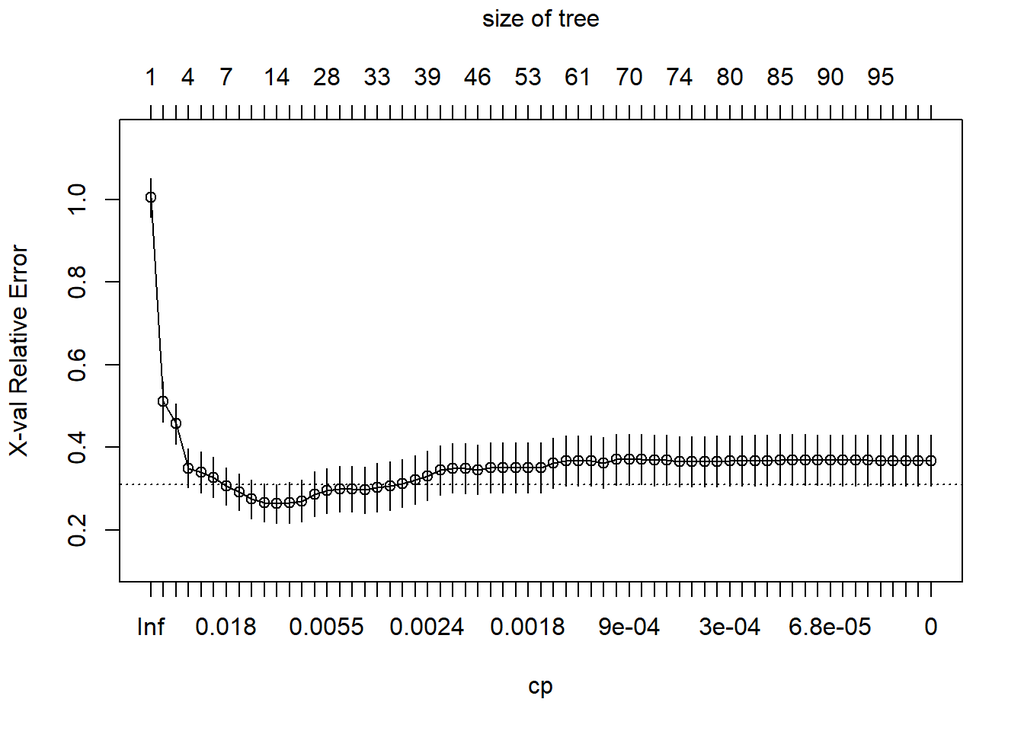

```r
plotcp(cart3)
```

```r
# min cp + 1 stddev
CVerror.cap <- cart3$cptable[which.min(cart3$cptable[,"xerror"]), "xerror"] +  cart3$cptable[which.min(cart3$cptable[,"xerror"]), "xstd"]

# Find the optimal CP region whose CV error is just below CVerror.cap in maximal tree cart3.
i <- 1; j<- 4
while (cart3$cptable[i,j] > CVerror.cap) {
  i <- i + 1
}
cp3 = ifelse(i > 1, sqrt(cart3$cptable[i,1] * cart3$cptable[i-1,1]), 1)

# create the next cart model, which is the optimal tree
cart4 <- prune(cart3, cp = cp3)
printcp(cart4, digits = 3)
```

```
##
## Regression tree:
## rpart(formula = Premium ~ ., data = trainset, method = "anova",
##     control = rpart.control(minsplit = 2, cp = 0))
##
## Variables actually used in tree construction:
## [1] Age            ChronicDisease Transplant     Weight
##
## Root node error: 67783119/691 = 98094
##
## n= 691
##
##       CP nsplit rel error xerror   xstd
## 1 0.4939      0     1.000  1.004 0.0476
## 2 0.0851      1     0.506  0.511 0.0490
## 3 0.0752      2     0.421  0.457 0.0491
## 4 0.0252      3     0.346  0.350 0.0473
## 5 0.0247      4     0.321  0.340 0.0492
## 6 0.0199      5     0.296  0.327 0.0488
## 7 0.0183      6     0.276  0.306 0.0449
```

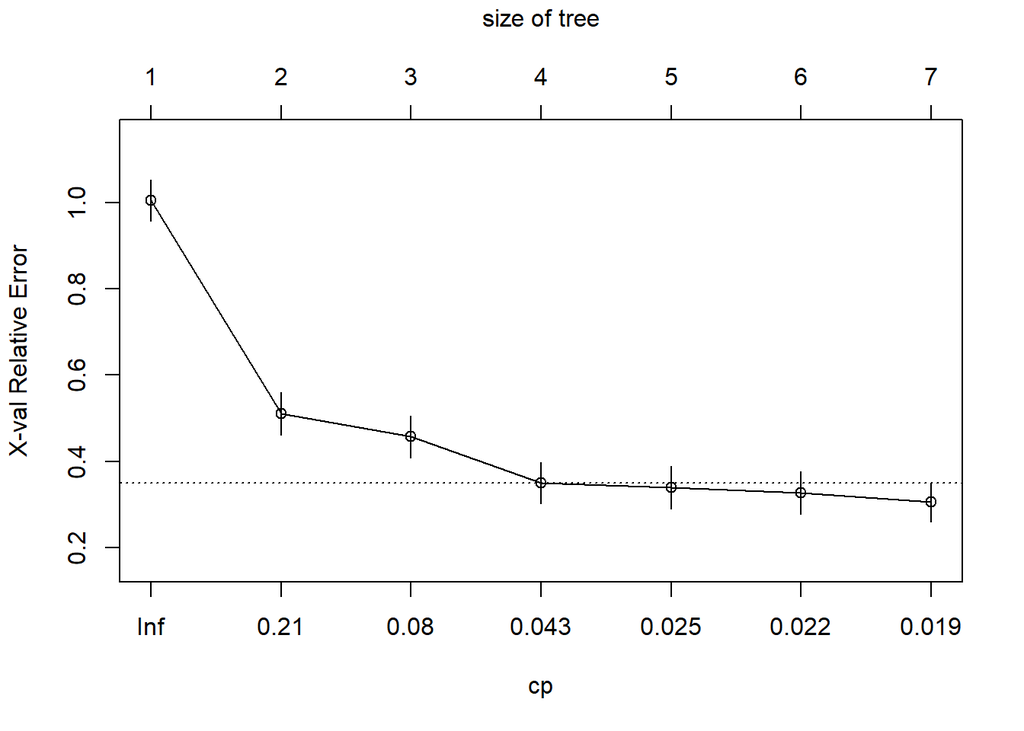

```r
plotcp(cart4)
```

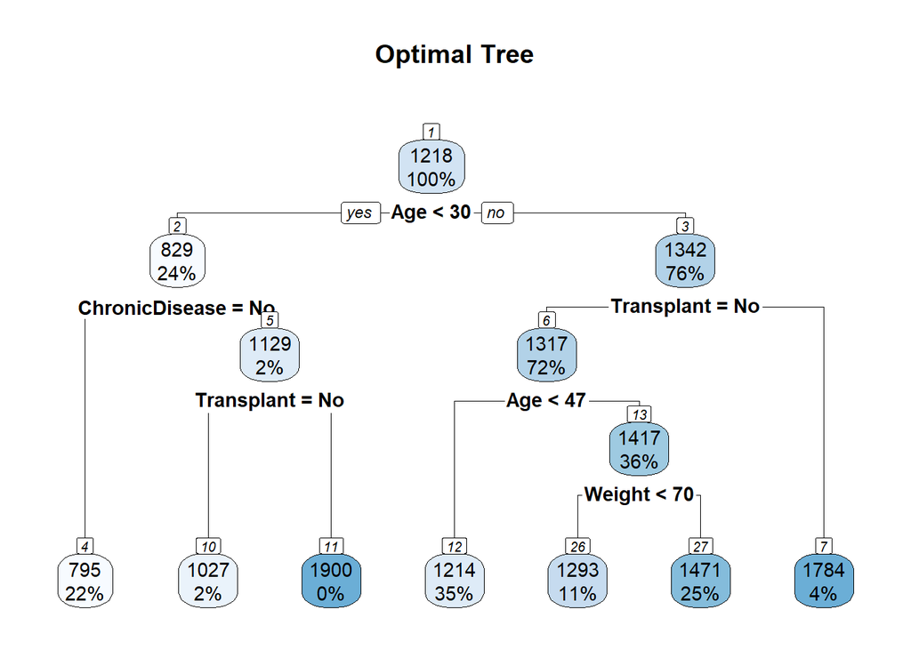

```r
# Root node error: 67783119/691 = 98094
# cart4 trainset MSE = 0.276 * 98094 = 27074
# cart4 CV MSE = 0.306 * 98094 = 30017

# plot the optimal tree
rpart.plot(cart4, nn = T, main = "Optimal Tree")
```

```r
## The number inside each node represent the mean value of Y.

# check the variable importance
cart4$variable.importance
```

```
##               Age        Transplant            Weight NumMajorSurgeries
##       38572809.21        7117012.41        2385536.49        1755018.73
##    ChronicDisease               BMI HighBloodPressure          Diabetes
##        1705034.25        1328573.26        1044654.01         626792.40
##            Height
##          22021.44
```

```r
summary(cart4)
```

```
## Call:
## rpart(formula = Premium ~ ., data = trainset, method = "anova",
##     control = rpart.control(minsplit = 2, cp = 0))
##   n= 691
##
##           CP nsplit rel error    xerror       xstd
## 1 0.49385302      0 1.0000000 1.0044927 0.04757124
## 2 0.08513995      1 0.5061470 0.5107308 0.04904155
## 3 0.07520916      2 0.4210070 0.4570391 0.04907520
## 4 0.02515426      3 0.3457979 0.3498610 0.04733280
## 5 0.02469095      4 0.3206436 0.3400208 0.04918297
## 6 0.01985687      5 0.2959527 0.3272613 0.04882071
## 7 0.01831055      6 0.2760958 0.3058158 0.04491254
##
## Variable importance
##               Age        Transplant            Weight NumMajorSurgeries
##                71                13                 4                 3
##    ChronicDisease               BMI HighBloodPressure          Diabetes
##                 3                 2                 2                 1
##
## Node number 1: 691 observations,    complexity param=0.493853
##   mean=1217.511, MSE=98094.24
##   left son=2 (168 obs) right son=3 (523 obs)
##   Primary splits:
##       Age               < 29.5  to the left,  improve=0.49385300, (0 missing)
##       Transplant        splits as  LR,        improve=0.06793150, (0 missing)
##       NumMajorSurgeries splits as  LLRR,      improve=0.05597647, (0 missing)
##       ChronicDisease    splits as  LR,        improve=0.05084534, (0 missing)
##       HighBloodPressure splits as  LR,        improve=0.03600284, (0 missing)
##   Surrogate splits:
##       Weight < 127.5 to the right, agree=0.760, adj=0.012, (0 split)
##       BMI    < 41.45 to the right, agree=0.758, adj=0.006, (0 split)
##
## Node number 2: 168 observations,    complexity param=0.02515426
##   mean=829.1667, MSE=57214.78
##   left son=4 (151 obs) right son=5 (17 obs)
##   Primary splits:
##       ChronicDisease    splits as  LR,        improve=0.17738450, (0 missing)
##       Weight            < 119   to the left,  improve=0.03932587, (0 missing)
##       Age               < 23.5  to the left,  improve=0.03671594, (0 missing)
```

[output cut: 57 more lines]

```
##   Primary splits:
##       Weight         < 69.5  to the left,  improve=0.25330730, (0 missing)
##       BMI            < 28.8  to the left,  improve=0.17955410, (0 missing)
##       CancerInFamily splits as  LR,        improve=0.02851091, (0 missing)
##       ChronicDisease splits as  LR,        improve=0.02400247, (0 missing)
##       Age            < 64.5  to the left,  improve=0.02350807, (0 missing)
##   Surrogate splits:
##       BMI    < 22.45 to the left,  agree=0.849, adj=0.500, (0 split)
##       Height < 147.5 to the left,  agree=0.701, adj=0.013, (0 split)
##
## Node number 26: 76 observations
##   mean=1293.421, MSE=8180.402
##
## Node number 27: 175 observations
##   mean=1471.143, MSE=24638.69
```

```r
# =========================================================================
```

```r
# predict on the testset
cart_predict <- predict(cart4, newdata = testset)

# calculating rmse
cart_error <- testset$Premium - cart_predict
cart_square_error <- cart_error^2
cart_mean_square_error <- mean(cart_square_error)
cart_root_mean_square_error <- sqrt(cart_mean_square_error)

summary(abs(cart_error))
```

```
##     Min.  1st Qu.   Median     Mean  3rd Qu.     Max.
##    4.636   45.364   64.344  101.973   78.857 1154.636
```

```r
cart_root_mean_square_error
```

```
## [1] 160.9869
```

We need to retrain the linreg model only on training data, then predict

```r
# ================= Repeating earlier code for train-test =================

# now that we know the optimal linear regression model, we put it through 10-fold cross validation, same as CART
# specify the 10-fold cross validation
train.control <- trainControl(method = "cv", number = 10)
linreg5 <- train(Premium ~ Age + Transplant + ChronicDisease + Weight + CancerInFamily + NumMajorSurgeries,
               data = trainset, method = "lm", trControl = train.control)
summary(linreg5)
```

```
##
## Call:
## lm(formula = .outcome ~ ., data = dat)
##
## Residuals:
##     Min      1Q  Median      3Q     Max
## -636.01 -103.13  -19.56   93.74 1194.46
##
## Coefficients:
##                     Estimate Std. Error t value Pr(>|t|)
## (Intercept)         176.1634    45.8408   3.843 0.000133 ***
## Age                  16.9382     0.5920  28.610  < 2e-16 ***
## TransplantYes       374.2233    31.0982  12.034  < 2e-16 ***
## ChronicDiseaseYes   154.6869    18.5496   8.339 4.13e-16 ***
## Weight                3.6871     0.4887   7.545 1.45e-13 ***
## CancerInFamilyYes   105.3020    23.7009   4.443 1.04e-05 ***
## NumMajorSurgeries1   10.5158    17.1502   0.613 0.539977
## NumMajorSurgeries2  -91.0704    25.9562  -3.509 0.000480 ***
## NumMajorSurgeries3 -130.9339    62.3848  -2.099 0.036201 *
## ---
## Signif. codes:  0 '***' 0.001 '**' 0.01 '*' 0.05 '.' 0.1 ' ' 1
##
## Residual standard error: 188.2 on 682 degrees of freedom
## Multiple R-squared:  0.6435, Adjusted R-squared:  0.6394
## F-statistic: 153.9 on 8 and 682 DF,  p-value: < 2.2e-16
```

```r
# vif(linreg5) # does not work with this library, but not necessary to know this at this stage anyway
print(linreg5)
```

```
## Linear Regression
##
## 691 samples
##   6 predictor
##
## No pre-processing
## Resampling: Cross-Validated (10 fold)
## Summary of sample sizes: 621, 622, 622, 623, 622, 623, ...
## Resampling results:
##
##   RMSE      Rsquared   MAE
##   189.2339  0.6426966  134.5608
##
## Tuning parameter 'intercept' was held constant at a value of TRUE
```

```r
# =========================================================================
```

```r
# predict on the testset
linreg_predict <- predict(linreg5, newdata = testset)

# calculating rmse
linreg_error <- testset$Premium - linreg_predict
linreg_square_error <- linreg_error^2
linreg_mean_square_error <- mean(linreg_square_error)
linreg_root_mean_square_error <- sqrt(linreg_mean_square_error)

summary(abs(linreg_error))
```

```
##     Min.  1st Qu.   Median     Mean  3rd Qu.     Max.
##    0.208   56.302  114.143  135.139  179.595 1145.290
```

```r
linreg_root_mean_square_error
```

```
## [1] 182.4656
```

```r
uniqueN(testset$Premium)
```

```
## [1] 20
```

```r
uniqueN(cart_predict)
```

```
## [1] 7
```

```r
uniqueN(linreg_predict)
```

```
## [1] 295
```

# Question 5

Explain the limitations of your analysis. [Max 1 page.]

# Question 6

Is CART successful in this application? Explain. [Max 1 page.]